# Notebook

## **AI Admission Predictor**

```python
# import sys
# from pathlib import Path

# import matplotlib.pyplot as plt
# import pandas as pd
# import seaborn as sns

# PROJECT_ROOT = Path.cwd().parent
# SRC_DIR = PROJECT_ROOT / "src"
# sys.path.insert(0, str(SRC_DIR))

# from preprocessing import clean_data, load_raw_data

# df = clean_data(load_raw_data())
# df.head()
```

```python
# sns.pairplot(df, corner=True)
# plt.show()
```

```python
# from train_model import main as train_main

# train_main()
```

### **Phase 1 — Import, Load & Inspect the required Libraries & Dataset**

```python
# ============================================
# Data Manipulation
# ============================================
import pandas as pd
import numpy as np

# ============================================
# Data Visualization
# ============================================
import matplotlib.pyplot as plt

# Display settings
pd.set_option("display.max_columns", None)
pd.set_option("display.max_rows", 100)

print("Libraries imported successfully.")
```

```
Libraries imported successfully.
```

```python
pd.set_option("display.max_columns", None)
```

```python
pd.set_option("display.max_rows", 100)
```

**Step 1.1 — Upload the Dataset to Google Colab**

```python
from google.colab import files

uploaded = files.upload()
```

Upload widget is only available when the cell has been executed in the current browser session. Please rerun this cell to enable.

```
Saving Admission_Predict.csv to Admission_Predict.csv
```

**Step 1.2 — Load the Dataset and Display First Five and last Five Rows**

```python
df = pd.read_csv("Admission_Predict.csv")
```

```python
df.head()
```

|  | Serial No. | GRE Score | TOEFL Score | University Rating | SOP | LOR | CGPA | Research | Chance of Admit |
| --- | --- | --- | --- | --- | --- | --- | --- | --- | --- |
| 0 | 1 | 337 | 118 | 4 | 4.5 | 4.5 | 9.65 | 1 | 0.92 |
| 1 | 2 | 324 | 107 | 4 | 4.0 | 4.5 | 8.87 | 1 | 0.76 |
| 2 | 3 | 316 | 104 | 3 | 3.0 | 3.5 | 8.00 | 1 | 0.72 |
| 3 | 4 | 322 | 110 | 3 | 3.5 | 2.5 | 8.67 | 1 | 0.80 |
| 4 | 5 | 314 | 103 | 2 | 2.0 | 3.0 | 8.21 | 0 | 0.65 |

```python
df.tail()
```

|  | Serial No. | GRE Score | TOEFL Score | University Rating | SOP | LOR | CGPA | Research | Chance of Admit |
| --- | --- | --- | --- | --- | --- | --- | --- | --- | --- |
| 395 | 396 | 324 | 110 | 3 | 3.5 | 3.5 | 9.04 | 1 | 0.82 |
| 396 | 397 | 325 | 107 | 3 | 3.0 | 3.5 | 9.11 | 1 | 0.84 |
| 397 | 398 | 330 | 116 | 4 | 5.0 | 4.5 | 9.45 | 1 | 0.91 |
| 398 | 399 | 312 | 103 | 3 | 3.5 | 4.0 | 8.78 | 0 | 0.67 |
| 399 | 400 | 333 | 117 | 4 | 5.0 | 4.0 | 9.66 | 1 | 0.95 |

**Step 1.3 — Determine the Dataset Shape**

```python
df.shape
```

```
(400, 9)
```

**Step 1.4 — View the Column Names**

```python
df.columns
```

```
Index(['Serial No.', 'GRE Score', 'TOEFL Score', 'University Rating', 'SOP',
       'LOR ', 'CGPA', 'Research', 'Chance of Admit '],
      dtype='object')
```

**Step 1.5 — Check Data Types**

```python
df.dtypes
```

|  | 0 |
| --- | --- |
| Serial No. | int64 |
| GRE Score | int64 |
| TOEFL Score | int64 |
| University Rating | int64 |
| SOP | float64 |
| LOR | float64 |
| CGPA | float64 |
| Research | int64 |
| Chance of Admit | float64 |

**dtype:** object

**Step 1.6 — Display General Dataset Information**

```python
df.info()
```

```
<class 'pandas.core.frame.DataFrame'>
RangeIndex: 400 entries, 0 to 399
Data columns (total 9 columns):
 #   Column             Non-Null Count  Dtype
---  ------             --------------  -----
 0   Serial No.         400 non-null    int64
 1   GRE Score          400 non-null    int64
 2   TOEFL Score        400 non-null    int64
 3   University Rating  400 non-null    int64
 4   SOP                400 non-null    float64
 5   LOR                400 non-null    float64
 6   CGPA               400 non-null    float64
 7   Research           400 non-null    int64
 8   Chance of Admit    400 non-null    float64
dtypes: float64(4), int64(5)
memory usage: 28.3 KB
```

**Step 1.7 — Generate Summary Statistics**

```python
df.describe()
```

|  | Serial No. | GRE Score | TOEFL Score | University Rating | SOP | LOR | CGPA | Research | Chance of Admit |
| --- | --- | --- | --- | --- | --- | --- | --- | --- | --- |
| count | 400.000000 | 400.000000 | 400.000000 | 400.000000 | 400.000000 | 400.000000 | 400.000000 | 400.000000 | 400.000000 |
| mean | 200.500000 | 316.807500 | 107.410000 | 3.087500 | 3.400000 | 3.452500 | 8.598925 | 0.547500 | 0.724350 |
| std | 115.614301 | 11.473646 | 6.069514 | 1.143728 | 1.006869 | 0.898478 | 0.596317 | 0.498362 | 0.142609 |
| min | 1.000000 | 290.000000 | 92.000000 | 1.000000 | 1.000000 | 1.000000 | 6.800000 | 0.000000 | 0.340000 |
| 25% | 100.750000 | 308.000000 | 103.000000 | 2.000000 | 2.500000 | 3.000000 | 8.170000 | 0.000000 | 0.640000 |
| 50% | 200.500000 | 317.000000 | 107.000000 | 3.000000 | 3.500000 | 3.500000 | 8.610000 | 1.000000 | 0.730000 |
| 75% | 300.250000 | 325.000000 | 112.000000 | 4.000000 | 4.000000 | 4.000000 | 9.062500 | 1.000000 | 0.830000 |
| max | 400.000000 | 340.000000 | 120.000000 | 5.000000 | 5.000000 | 5.000000 | 9.920000 | 1.000000 | 0.970000 |

```python
df.info()
```

```
<class 'pandas.core.frame.DataFrame'>
RangeIndex: 400 entries, 0 to 399
Data columns (total 9 columns):
 #   Column             Non-Null Count  Dtype
---  ------             --------------  -----
 0   Serial No.         400 non-null    int64
 1   GRE Score          400 non-null    int64
 2   TOEFL Score        400 non-null    int64
 3   University Rating  400 non-null    int64
 4   SOP                400 non-null    float64
 5   LOR                400 non-null    float64
 6   CGPA               400 non-null    float64
 7   Research           400 non-null    int64
 8   Chance of Admit    400 non-null    float64
dtypes: float64(4), int64(5)
memory usage: 28.3 KB
```

```python
df.describe()
```

|  | Serial No. | GRE Score | TOEFL Score | University Rating | SOP | LOR | CGPA | Research | Chance of Admit |
| --- | --- | --- | --- | --- | --- | --- | --- | --- | --- |
| count | 400.000000 | 400.000000 | 400.000000 | 400.000000 | 400.000000 | 400.000000 | 400.000000 | 400.000000 | 400.000000 |
| mean | 200.500000 | 316.807500 | 107.410000 | 3.087500 | 3.400000 | 3.452500 | 8.598925 | 0.547500 | 0.724350 |
| std | 115.614301 | 11.473646 | 6.069514 | 1.143728 | 1.006869 | 0.898478 | 0.596317 | 0.498362 | 0.142609 |
| min | 1.000000 | 290.000000 | 92.000000 | 1.000000 | 1.000000 | 1.000000 | 6.800000 | 0.000000 | 0.340000 |
| 25% | 100.750000 | 308.000000 | 103.000000 | 2.000000 | 2.500000 | 3.000000 | 8.170000 | 0.000000 | 0.640000 |
| 50% | 200.500000 | 317.000000 | 107.000000 | 3.000000 | 3.500000 | 3.500000 | 8.610000 | 1.000000 | 0.730000 |
| 75% | 300.250000 | 325.000000 | 112.000000 | 4.000000 | 4.000000 | 4.000000 | 9.062500 | 1.000000 | 0.830000 |
| max | 400.000000 | 340.000000 | 120.000000 | 5.000000 | 5.000000 | 5.000000 | 9.920000 | 1.000000 | 0.970000 |

```python
df.columns
```

```
Index(['Serial No.', 'GRE Score', 'TOEFL Score', 'University Rating', 'SOP',
       'LOR ', 'CGPA', 'Research', 'Chance of Admit '],
      dtype='object')
```

### **Phase 2 — Data Cleaning**

**Step 2.1 – Create a Copy of the Dataset**

```python
# Create a copy of the original dataset
df_clean = df.copy()

print("Dataset copied successfully.")
```

```
Dataset copied successfully.
```

**Step 2.2 – Inspect Column Names**

```python
# Display all column names
print(df_clean.columns.tolist())
```

```
['Serial No.', 'GRE Score', 'TOEFL Score', 'University Rating', 'SOP', 'LOR ', 'CGPA', 'Research', 'Chance of Admit ']
```

**Step 2.3 – Remove Leading and Trailing Spaces**

```python
# Remove extra spaces from column names
df_clean.columns = df_clean.columns.str.strip()

# Verify the changes
print(df_clean.columns.tolist())
```

```
['Serial No.', 'GRE Score', 'TOEFL Score', 'University Rating', 'SOP', 'LOR', 'CGPA', 'Research', 'Chance of Admit']
```

**Step 2.4 – Standardize Column Names**

```python
# Standardize column names
df_clean.columns = [
    "serial_no",
    "gre_score",
    "toefl_score",
    "university_rating",
    "sop",
    "lor",
    "cgpa",
    "research",
    "chance_of_admit"
]

print(df_clean.columns.tolist())
```

```
['serial_no', 'gre_score', 'toefl_score', 'university_rating', 'sop', 'lor', 'cgpa', 'research', 'chance_of_admit']
```

**Step 2.5 – Check for Missing Values**

```python
# Check missing values
missing_values = df_clean.isnull().sum()

print(missing_values)
```

```
serial_no            0
gre_score            0
toefl_score          0
university_rating    0
sop                  0
lor                  0
cgpa                 0
research             0
chance_of_admit      0
dtype: int64
```

**Step 2.6 – Check for Duplicate Rows**

```python
# Check for duplicate rows
duplicates = df_clean.duplicated().sum()

print(f"Number of duplicate rows: {duplicates}")
```

```
Number of duplicate rows: 0
```

**Step 2.7 – Check Data Types Again**

```python
df_clean.dtypes
```

|  | 0 |
| --- | --- |
| serial_no | int64 |
| gre_score | int64 |
| toefl_score | int64 |
| university_rating | int64 |
| sop | float64 |
| lor | float64 |
| cgpa | float64 |
| research | int64 |
| chance_of_admit | float64 |

**dtype:** object

**Step 2.8 – Validate Numerical Ranges**

```python
# Minimum values
print(df_clean.min())

# Maximum values
print(df_clean.max())
```

```
serial_no              1.00
gre_score            290.00
toefl_score           92.00
university_rating      1.00
sop                    1.00
lor                    1.00
cgpa                   6.80
research               0.00
chance_of_admit        0.34
dtype: float64
serial_no            400.00
gre_score            340.00
toefl_score          120.00
university_rating      5.00
sop                    5.00
lor                    5.00
cgpa                   9.92
research               1.00
chance_of_admit        0.97
dtype: float64
```

**Step 2.9 – Remove the Serial Number Column**

```python
# Remove the identifier column
df_clean.drop(columns=["serial_no"], inplace=True)

print(df_clean.head())
```

```
   gre_score  toefl_score  university_rating  sop  lor  cgpa  research  \
0        337          118                  4  4.5  4.5  9.65         1
1        324          107                  4  4.0  4.5  8.87         1
2        316          104                  3  3.0  3.5  8.00         1
3        322          110                  3  3.5  2.5  8.67         1
4        314          103                  2  2.0  3.0  8.21         0

   chance_of_admit
0             0.92
1             0.76
2             0.72
3             0.80
4             0.65
```

**Step 2.10 – Save the Cleaned Dataset**

```python
df_clean.to_csv("admission_cleaned.csv", index=False)

print("Cleaned dataset saved successfully.")
```

```
Cleaned dataset saved successfully.
```

**Step 2.11 – Download the Cleaned Dataset**

```python
# files.download("admission_cleaned.csv")
```

### **Phase 3 – Feature Engineering**

**Step 3.1 – Create the Program Feature**

```python
def assign_program(row):
    if row["gre_score"] >= 330 and row["cgpa"] >= 9.2:
        return "Computer Science"
    elif row["gre_score"] >= 325 and row["cgpa"] >= 9.0:
        return "Data Science"
    elif row["gre_score"] >= 320 and row["cgpa"] >= 8.8:
        return "Artificial Intelligence"
    elif row["gre_score"] >= 315 and row["cgpa"] >= 8.5:
        return "Software Engineering"
    elif row["gre_score"] >= 310 and row["cgpa"] >= 8.2:
        return "Information Technology"
    else:
        return "Computer Engineering"

df_clean["program"] = df_clean.apply(assign_program, axis=1)
```

**Step 3.2 – Create the Application Completion Feature**

```python
df_clean["application_completion"] = np.where(
    (df_clean["research"] == 1) &
    (df_clean["sop"] >= 3.5) &
    (df_clean["lor"] >= 3.5),
    "Complete",
    "Incomplete"
)
```

**Step 3.3 – Create the Gender Feature**

```python
np.random.seed(42)

df_clean["gender"] = np.random.choice(
    ["Male", "Female"],
    size=len(df_clean),
    p=[0.5, 0.5]
)
```

**Step 3.4 – Create the Binary Target**

```python
# Choosing a Threshold
# The median value from your summary statistics is approximately 0.73.
# Instead of choosing 0.75 arbitrarily, we'll use 0.73, which naturally splits the dataset around its midpoint and tends to produce a more balanced classification problem.

THRESHOLD = 0.73

df_clean["admitted"] = (
    df_clean["chance_of_admit"] >= THRESHOLD
).astype(int)
```

**Step 3.5 – Explore the New Features**

```python
df_clean["program"].value_counts()
```

| program | count |
| --- | --- |
| Computer Engineering | 140 |
| Information Technology | 70 |
| Software Engineering | 60 |
| Computer Science | 50 |
| Artificial Intelligence | 43 |
| Data Science | 37 |

**dtype:** int64

```python
df_clean["application_completion"].value_counts()
```

| application_completion | count |
| --- | --- |
| Incomplete | 264 |
| Complete | 136 |

**dtype:** int64

```python
df_clean["gender"].value_counts()
```

| gender | count |
| --- | --- |
| Female | 207 |
| Male | 193 |

**dtype:** int64

```python
df_clean["admitted"].value_counts()
```

| admitted | count |
| --- | --- |
| 1 | 204 |
| 0 | 196 |

**dtype:** int64

```python
# Display the first five rows
df_clean.head()
```

|  | gre_score | toefl_score | university_rating | sop | lor | cgpa | research | chance_of_admit | program | application_completion | gender | admitted |
| --- | --- | --- | --- | --- | --- | --- | --- | --- | --- | --- | --- | --- |
| 0 | 337 | 118 | 4 | 4.5 | 4.5 | 9.65 | 1 | 0.92 | Computer Science | Complete | Male | 1 |
| 1 | 324 | 107 | 4 | 4.0 | 4.5 | 8.87 | 1 | 0.76 | Artificial Intelligence | Complete | Female | 1 |
| 2 | 316 | 104 | 3 | 3.0 | 3.5 | 8.00 | 1 | 0.72 | Computer Engineering | Incomplete | Female | 0 |
| 3 | 322 | 110 | 3 | 3.5 | 2.5 | 8.67 | 1 | 0.80 | Software Engineering | Incomplete | Female | 1 |
| 4 | 314 | 103 | 2 | 2.0 | 3.0 | 8.21 | 0 | 0.65 | Information Technology | Incomplete | Male | 0 |

```python
# Display the last five rows
df_clean.tail()
```

|  | gre_score | toefl_score | university_rating | sop | lor | cgpa | research | chance_of_admit | program | application_completion | gender | admitted |
| --- | --- | --- | --- | --- | --- | --- | --- | --- | --- | --- | --- | --- |
| 395 | 324 | 110 | 3 | 3.5 | 3.5 | 9.04 | 1 | 0.82 | Artificial Intelligence | Complete | Female | 1 |
| 396 | 325 | 107 | 3 | 3.0 | 3.5 | 9.11 | 1 | 0.84 | Data Science | Incomplete | Female | 1 |
| 397 | 330 | 116 | 4 | 5.0 | 4.5 | 9.45 | 1 | 0.91 | Computer Science | Complete | Male | 1 |
| 398 | 312 | 103 | 3 | 3.5 | 4.0 | 8.78 | 0 | 0.67 | Information Technology | Incomplete | Female | 0 |
| 399 | 333 | 117 | 4 | 5.0 | 4.0 | 9.66 | 1 | 0.95 | Computer Science | Complete | Female | 1 |

```python
# Verify the updated structure
df_clean.info()
```

```
<class 'pandas.core.frame.DataFrame'>
RangeIndex: 400 entries, 0 to 399
Data columns (total 12 columns):
 #   Column                  Non-Null Count  Dtype
---  ------                  --------------  -----
 0   gre_score               400 non-null    int64
 1   toefl_score             400 non-null    int64
 2   university_rating       400 non-null    int64
 3   sop                     400 non-null    float64
 4   lor                     400 non-null    float64
 5   cgpa                    400 non-null    float64
 6   research                400 non-null    int64
 7   chance_of_admit         400 non-null    float64
 8   program                 400 non-null    object
 9   application_completion  400 non-null    object
 10  gender                  400 non-null    object
 11  admitted                400 non-null    int64
dtypes: float64(4), int64(5), object(3)
memory usage: 37.6+ KB
```

```python
# Check the data types of all columns
df_clean.dtypes
```

|  | 0 |
| --- | --- |
| gre_score | int64 |
| toefl_score | int64 |
| university_rating | int64 |
| sop | float64 |
| lor | float64 |
| cgpa | float64 |
| research | int64 |
| chance_of_admit | float64 |
| program | object |
| application_completion | object |
| gender | object |
| admitted | int64 |

**dtype:** object

**Step 3.6 – Save the Engineered Dataset**

```python
df_clean.to_csv(
    "admission_engineered.csv",
    index=False
)

print("Engineered dataset saved successfully.")
#files.download("admission_engineered.csv")
```

```
Engineered dataset saved successfully.
```

### **Phase 4 – Exploratory Data Analysis (EDA)**

**Step 4.1 – Import Visualization Libraries**

```python
# ============================================
# Data Visualization Libraries
# ============================================

import matplotlib.pyplot as plt

# Set figure size
plt.rcParams["figure.figsize"] = (10, 6)

# Increase font sizes
plt.rcParams["font.size"] = 12

print("Visualization libraries loaded successfully.")
```

```
Visualization libraries loaded successfully.
```

**Step 4.2 – Admission Distribution**

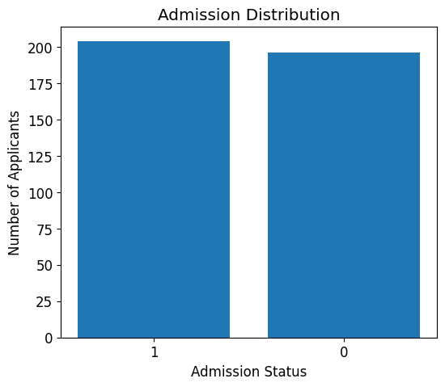

```python
# Checking whether the dataset is balanced after converting the target variable.
admission_counts = df_clean["admitted"].value_counts()

plt.figure(figsize=(6,5))
plt.bar(
    admission_counts.index.astype(str),
    admission_counts.values
)

plt.title("Admission Distribution")
plt.xlabel("Admission Status")
plt.ylabel("Number of Applicants")

plt.show()
```

**Step 4.3 – GRE Score Distribution**

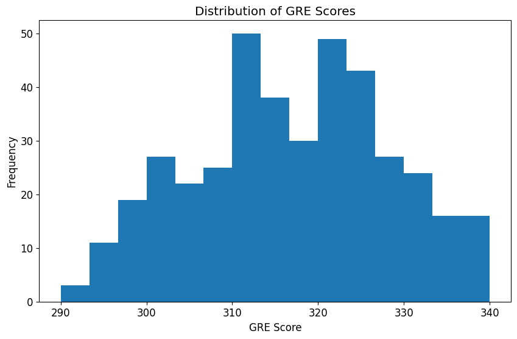

```python
plt.hist(df_clean["gre_score"], bins=15)

plt.title("Distribution of GRE Scores")
plt.xlabel("GRE Score")
plt.ylabel("Frequency")

plt.show()
```

**Step 4.4 – TOEFL Score Distribution**

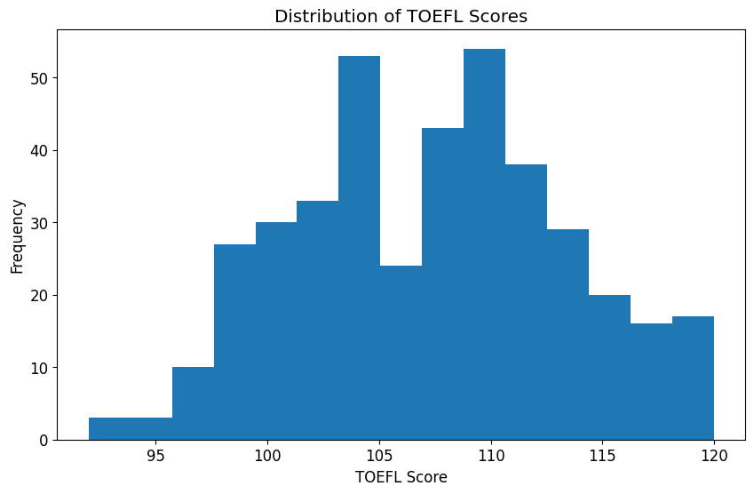

```python
plt.hist(df_clean["toefl_score"], bins=15)

plt.title("Distribution of TOEFL Scores")
plt.xlabel("TOEFL Score")
plt.ylabel("Frequency")

plt.show()
```

**Step 4.5 – CGPA Distribution**

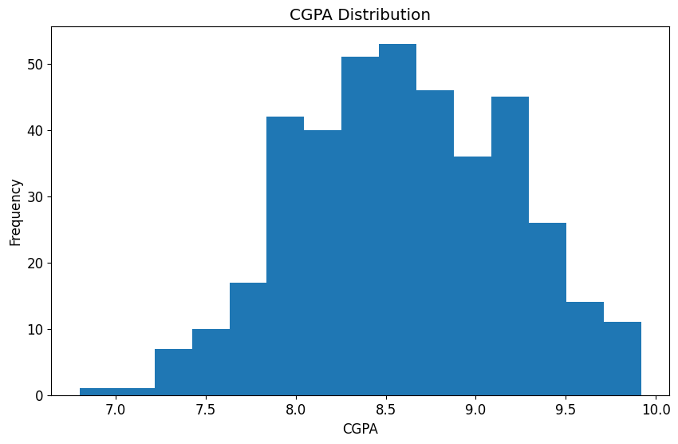

```python
plt.hist(df_clean["cgpa"], bins=15)

plt.title("CGPA Distribution")
plt.xlabel("CGPA")
plt.ylabel("Frequency")

plt.show()
```

**Step 4.6 – University Rating**

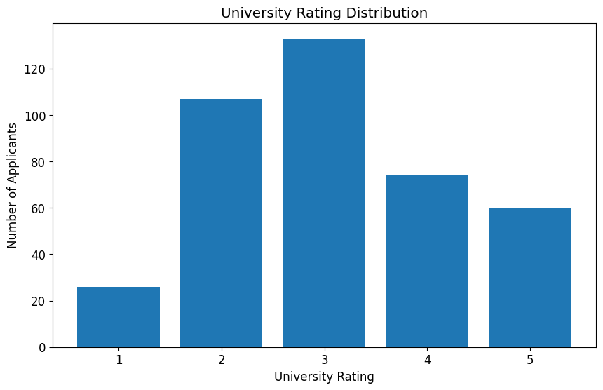

```python
rating_counts = df_clean["university_rating"].value_counts().sort_index()

plt.bar(
    rating_counts.index.astype(str),
    rating_counts.values
)

plt.title("University Rating Distribution")
plt.xlabel("University Rating")
plt.ylabel("Number of Applicants")

plt.show()
```

**Step 4.7 – SOP Distribution**

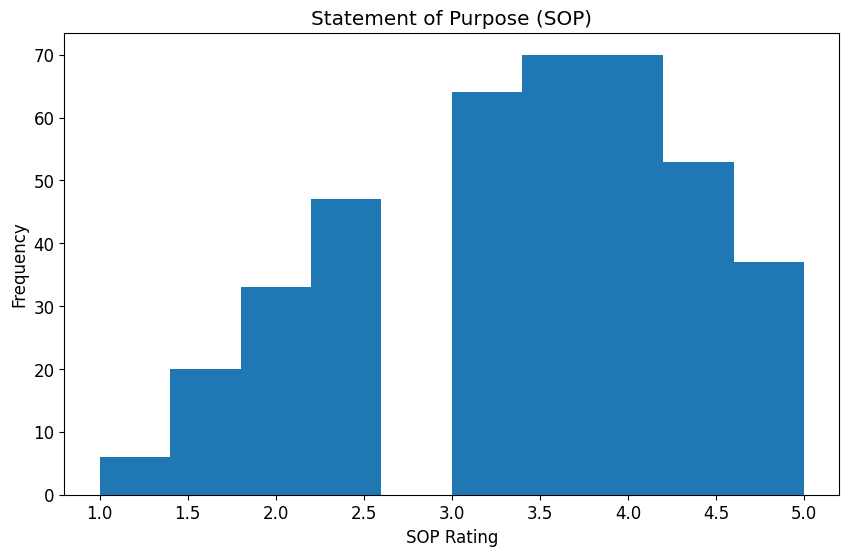

```python
plt.hist(df_clean["sop"], bins=10)

plt.title("Statement of Purpose (SOP)")
plt.xlabel("SOP Rating")
plt.ylabel("Frequency")

plt.show()
```

**Step 4.8 – LOR Distribution**

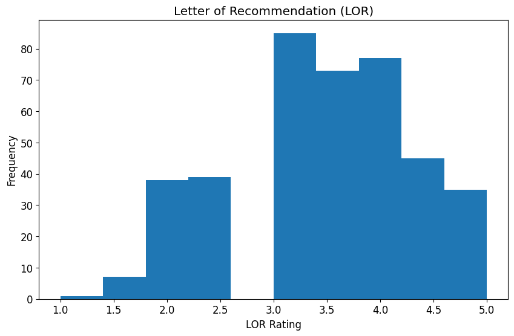

```python
plt.hist(df_clean["lor"], bins=10)

plt.title("Letter of Recommendation (LOR)")
plt.xlabel("LOR Rating")
plt.ylabel("Frequency")

plt.show()
```

**Step 4.9 – Research vs Admission**

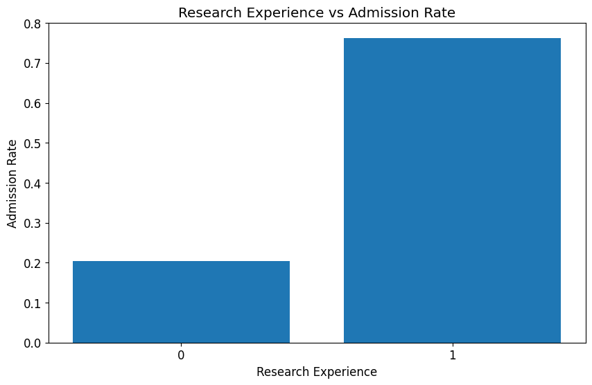

```python
research_admission = (
    df_clean.groupby("research")["admitted"]
    .mean()
)

plt.bar(
    research_admission.index.astype(str),
    research_admission.values
)

plt.title("Research Experience vs Admission Rate")
plt.xlabel("Research Experience")
plt.ylabel("Admission Rate")

plt.show()
```

**Step 4.10 – Program vs Admission**

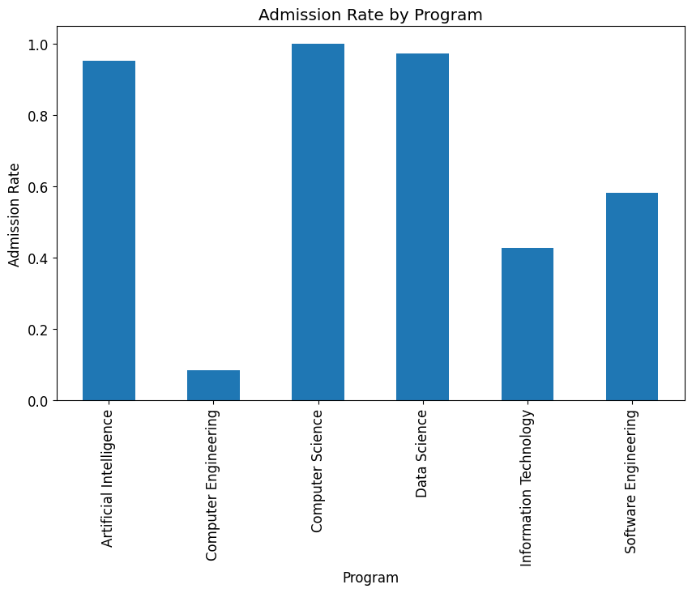

```python
program_admission = (
    df_clean.groupby("program")["admitted"]
    .mean()
)

program_admission.plot(kind="bar")

plt.title("Admission Rate by Program")
plt.xlabel("Program")
plt.ylabel("Admission Rate")

plt.show()
```

**Step 4.11 – Gender vs Admission**

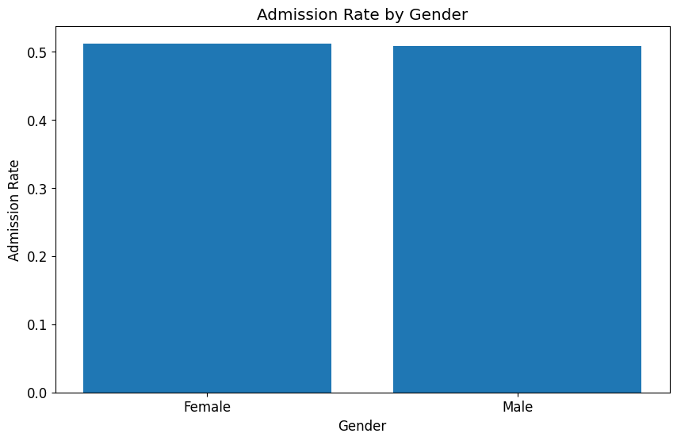

```python
gender_admission = (
    df_clean.groupby("gender")["admitted"]
    .mean()
)

plt.bar(
    gender_admission.index,
    gender_admission.values
)

plt.title("Admission Rate by Gender")
plt.xlabel("Gender")
plt.ylabel("Admission Rate")

plt.show()
```

**Step 4.12 – Correlation Heatmap**

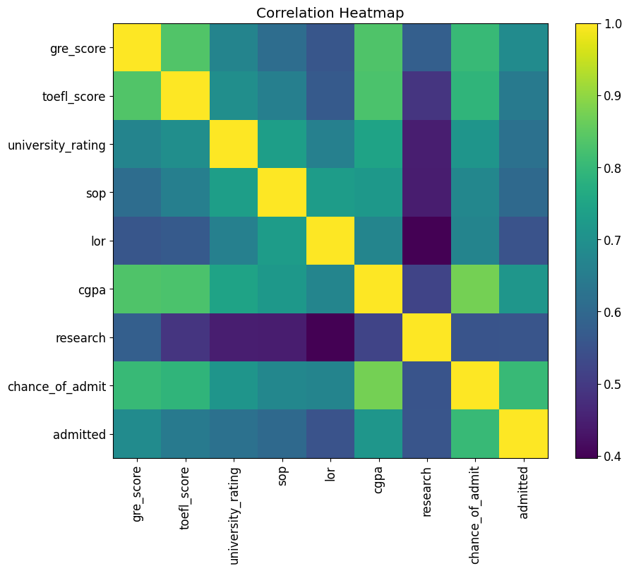

```python
correlation_matrix = df_clean.corr(numeric_only=True)

plt.figure(figsize=(10, 8))

plt.imshow(correlation_matrix)

plt.colorbar()

plt.xticks(
    range(len(correlation_matrix.columns)),
    correlation_matrix.columns,
    rotation=90
)

plt.yticks(
    range(len(correlation_matrix.columns)),
    correlation_matrix.columns
)

plt.title("Correlation Heatmap")

plt.show()
```

**Step 4.13 – Exploratory Data Analysis (EDA) Summary**

#### **Exploratory Data Analysis (EDA) Summary**

#### Overview

The Exploratory Data Analysis (EDA) phase was conducted to understand the structure of the dataset, identify patterns among the variables, and discover relationships that may influence graduate admission decisions. Several univariate and bivariate visualizations were created to examine the distribution of academic features and their relationship with the admission outcome.

#### 1. Balanced Admission Classes

The admission distribution shows that the dataset is well balanced, with approximately equal numbers of admitted and non-admitted applicants.

- Admitted: 204 applicants
- Not Admitted: 196 applicants

A balanced target variable is beneficial because it reduces the likelihood of model bias toward one class and provides a suitable foundation for supervised classification.

#### 2. GRE Scores

The GRE score distribution approximates a bell-shaped curve with most applicants scoring between 310 and 325.

This indicates that applicants generally possess competitive GRE scores, while extremely low or exceptionally high scores are relatively uncommon.

#### 3. TOEFL Scores

Most TOEFL scores fall between 100 and 112.

The distribution suggests that applicants generally demonstrate strong English language proficiency, which is expected for graduate school applications.

#### 4. CGPA Distribution

Applicant CGPAs are concentrated between 8.0 and 9.3 on a 10-point grading scale.

The distribution indicates that most candidates have strong academic performance, with relatively few applicants having low CGPAs.

#### 5. University Rating

Applicants originate primarily from universities with ratings between 2 and 4.

University rating 3 appears most frequently, suggesting that applicants from mid-ranked institutions make up the largest proportion of the dataset.

#### 6. Statement of Purpose (SOP)

Most SOP ratings lie between 3 and 4.

This indicates that the majority of applicants submitted reasonably strong statements of purpose rather than exceptionally weak or outstanding ones.

#### 7. Letter of Recommendation (LOR)

The LOR ratings follow a distribution similar to the SOP ratings.

Most applicants received recommendation scores between 3 and 4.5, indicating generally positive academic recommendations.

#### 8. Research Experience

Applicants with research experience exhibit substantially higher admission rates than applicants without research experience.

This suggests that research experience is an important characteristic associated with successful graduate school applications.

#### 9. Program Distribution

Admission rates differ across the engineered program categories.

This pattern is expected because the program feature was created using rule-based thresholds based on applicants' GRE scores and CGPA. Therefore, programs associated with stronger academic profiles naturally display higher admission rates.

These results should not be interpreted as actual university admission statistics but rather as outcomes of the feature engineering process.

#### 10. Gender Distribution

The admission rate is nearly identical for both male and female applicants.

This observation is expected because the gender feature was synthetically generated for demonstration purposes and does not represent actual applicant demographics.

Consequently, no real-world conclusions regarding gender and admission decisions should be drawn from this feature.

#### 11. Correlation Analysis

The correlation heatmap indicates that several academic variables are positively associated with admission probability.

These variables appear to contribute most strongly to admission outcomes and are expected to play significant roles during model training.

No severe multicollinearity is observed that would prevent the use of standard machine learning algorithms.

### Overall Conclusion

The exploratory analysis demonstrates that the dataset is clean, well balanced, and suitable for machine learning.

The engineered features successfully satisfy the project requirements while maintaining logical consistency within the dataset.

The dataset is now fully prepared for the machine learning phase, where multiple classification algorithms will be trained, evaluated, and compared to identify the best-performing admission prediction model.

### **Phase 5 – Data Preprocessing & Machine Learning Pipeline**

**Step 5.1 – Import Machine Learning Libraries**

```python
# ============================================
# Machine Learning Libraries
# ============================================

from sklearn.model_selection import train_test_split

from sklearn.preprocessing import (
    LabelEncoder,
    StandardScaler
)

from sklearn.compose import ColumnTransformer
from sklearn.pipeline import Pipeline
from sklearn.impute import SimpleImputer
from sklearn.preprocessing import OneHotEncoder

import joblib

print("Machine Learning libraries imported successfully.")
```

```
Machine Learning libraries imported successfully.
```

**Step 5.2 – Separate Features and Target**

Our target variable is - admitted

```python
X = df_clean.drop(
    columns=[
        "admitted",
        "chance_of_admit"
    ]
)

print("Feature matrix shape:", X.shape)
print(X.columns)
```

```
Feature matrix shape: (400, 10)
Index(['gre_score', 'toefl_score', 'university_rating', 'sop', 'lor', 'cgpa',
       'research', 'program', 'application_completion', 'gender'],
      dtype='object')
```

```python
print(X.columns.tolist())
print(len(X.columns))
```

```
['gre_score', 'toefl_score', 'university_rating', 'sop', 'lor', 'cgpa', 'research', 'program', 'application_completion', 'gender']
10
```

**Step 5.3 – Identify Numerical and Categorical Features**

```python
numerical_features = [
    "gre_score",
    "toefl_score",
    "university_rating",
    "sop",
    "lor",
    "cgpa",
    "research"
]

categorical_features = [
    "program",
    "gender",
    "application_completion"
]
```

```python
print("Numerical Features:")
print(numerical_features)

print("\nCategorical Features:")
print(categorical_features)
```

```
Numerical Features:
['gre_score', 'toefl_score', 'university_rating', 'sop', 'lor', 'cgpa', 'research']

Categorical Features:
['program', 'gender', 'application_completion']
```

**Step 5.4 – Build a Preprocessing Pipeline**

```python
# Preprocessing for numerical features
numeric_transformer = Pipeline(
    steps=[
        ("imputer", SimpleImputer(strategy="median")),
        ("scaler", StandardScaler())
    ]
)

# Preprocessing for categorical features
categorical_transformer = Pipeline(
    steps=[
        ("imputer", SimpleImputer(strategy="most_frequent")),
        ("encoder", OneHotEncoder(handle_unknown="ignore"))
    ]
)

# Combine preprocessing
preprocessor = ColumnTransformer(
    transformers=[
        ("num", numeric_transformer, numerical_features),
        ("cat", categorical_transformer, categorical_features)
    ]
)

print("Preprocessing pipeline created successfully.")
```

```
Preprocessing pipeline created successfully.
```

**Step 5.5 – Split the Dataset**

```python
X_train, X_test, y_train, y_test = train_test_split(
    X,
    y,
    test_size=0.20,
    random_state=42,
    stratify=y
)

print("Training set:", X_train.shape)
print("Testing set:", X_test.shape)
```

```
Training set: (320, 10)
Testing set: (80, 10)
```

**Step 5.6 – Fit the Preprocessor**

```python
# Learn preprocessing from the training data
preprocessor.fit(X_train)

# Transform the datasets
X_train_processed = preprocessor.transform(X_train)
X_test_processed = preprocessor.transform(X_test)

print("Training matrix shape:", X_train_processed.shape)
print("Testing matrix shape:", X_test_processed.shape)
```

```
Training matrix shape: (320, 17)
Testing matrix shape: (80, 17)
```

**Step 5.7 – Save the Preprocessor**

```python
joblib.dump(preprocessor, "preprocessor.pkl")

print("Preprocessor saved successfully.")
```

```
Preprocessor saved successfully.
```

### **Phase 6 – Model Development & Evaluation**

**Step 6.1 – Import Machine Learning Models**

```python
# ============================================
# Classification Models
# ============================================

from sklearn.linear_model import LogisticRegression
from sklearn.tree import DecisionTreeClassifier
from sklearn.ensemble import RandomForestClassifier
from sklearn.ensemble import GradientBoostingClassifier
from sklearn.svm import SVC
from sklearn.neighbors import KNeighborsClassifier

# Evaluation Metrics
from sklearn.metrics import (
    accuracy_score,
    precision_score,
    recall_score,
    f1_score,
    roc_auc_score,
    confusion_matrix,
    classification_report
)

print("Models imported successfully.")
```

```
Models imported successfully.
```

**Step 6.2 – Create the Models**

```python
models = {

    "Logistic Regression":
        LogisticRegression(random_state=42),

    "Decision Tree":
        DecisionTreeClassifier(random_state=42),

    "Random Forest":
        RandomForestClassifier(random_state=42),

    "Support Vector Machine":
        SVC(probability=True, random_state=42),

    "K-Nearest Neighbors":
        KNeighborsClassifier(),

    "Gradient Boosting":
        GradientBoostingClassifier(random_state=42)

}

print(f"{len(models)} models ready for training.")
```

```
6 models ready for training.
```

**Step 6.3 – Train Every Model**

```python
trained_models = {}

for name, model in models.items():

    model.fit(X_train_processed, y_train)

    trained_models[name] = model

print("All models trained successfully.")
```

```
All models trained successfully.
```

**Step 6.4 – Evaluate Every Model**

```python
results = []

for name, model in trained_models.items():

    predictions = model.predict(X_test_processed)

    probabilities = model.predict_proba(X_test_processed)[:, 1]

    accuracy = accuracy_score(y_test, predictions)

    precision = precision_score(y_test, predictions)

    recall = recall_score(y_test, predictions)

    f1 = f1_score(y_test, predictions)

    roc_auc = roc_auc_score(y_test, probabilities)

    results.append({

        "Model": name,

        "Accuracy": accuracy,

        "Precision": precision,

        "Recall": recall,

        "F1 Score": f1,

        "ROC AUC": roc_auc

    })

print("Evaluation completed.")
```

```
Evaluation completed.
```

**Step 6.5 – Create a Comparison Table**

```python
import pandas as pd

results_df = pd.DataFrame(results)

results_df = results_df.sort_values(
    by="Accuracy",
    ascending=False
)

results_df.reset_index(drop=True, inplace=True)

results_df
```

|  | Model | Accuracy | Precision | Recall | F1 Score | ROC AUC |
| --- | --- | --- | --- | --- | --- | --- |
| 0 | Logistic Regression | 0.8750 | 0.897436 | 0.853659 | 0.875000 | 0.960600 |
| 1 | Support Vector Machine | 0.8750 | 0.878049 | 0.878049 | 0.878049 | 0.954972 |
| 2 | Random Forest | 0.8625 | 0.894737 | 0.829268 | 0.860759 | 0.940275 |
| 3 | K-Nearest Neighbors | 0.8500 | 0.837209 | 0.878049 | 0.857143 | 0.927455 |
| 4 | Gradient Boosting | 0.8500 | 0.871795 | 0.829268 | 0.850000 | 0.944966 |
| 5 | Decision Tree | 0.8375 | 0.833333 | 0.853659 | 0.843373 | 0.837086 |

**Step 6.6 – Identify the Best Model**

```python
best_model_name = results_df.iloc[0]["Model"]

print("Best Model:", best_model_name)
```

```
Best Model: Logistic Regression
```

**Step 6.7 – Save the Best Model**

```python
best_model = trained_models[best_model_name]

joblib.dump(best_model, "best_model.pkl")

print("Best model saved successfully.")
```

```
Best model saved successfully.
```

**Step 6.8 – Detailed Evaluation of the Best Model**

```python
best_predictions = best_model.predict(X_test_processed)

print(classification_report(
    y_test,
    best_predictions
))
```

```
              precision    recall  f1-score   support

           0       0.85      0.90      0.88        39
           1       0.90      0.85      0.88        41

    accuracy                           0.88        80
   macro avg       0.88      0.88      0.88        80
weighted avg       0.88      0.88      0.88        80
```

**Step 6.9 – Confusion Matrix**

Interpretation:

Top-left: Correctly predicted "Not Admitted"

Bottom-right: Correctly predicted "Admitted"

Off-diagonal values: Misclassifications

```python
cm = confusion_matrix(
    y_test,
    best_predictions
)

print(cm)
```

```
[[35  4]
 [ 6 35]]
```

```python
if hasattr(best_model, "feature_importances_"):

    feature_names = (
        preprocessor.get_feature_names_out()
    )

    importance_df = pd.DataFrame({

        "Feature": feature_names,

        "Importance": best_model.feature_importances_

    })

    importance_df = importance_df.sort_values(
        by="Importance",
        ascending=False
    )

    importance_df.head(10)
```

### **Phase 7 – Hyperparameter Tuning & Model Optimization**

**Step 7.1 – Define the Parameter Grid**

```python
param_grid = {
    "C": [0.01, 0.1, 1, 10, 100],
    "solver": ["liblinear", "lbfgs"],
    "penalty": ["l2"]
}
```

**Step 7.2 – Import GridSearchCV**

```python
from sklearn.model_selection import GridSearchCV
```

**Step 7.3 – Run Grid Search**

```python
grid_search = GridSearchCV(
    estimator=LogisticRegression(random_state=42),
    param_grid=param_grid,
    cv=5,
    scoring="accuracy",
    n_jobs=-1
)

grid_search.fit(
    X_train_processed,
    y_train
)
```

```
GridSearchCV(cv=5, estimator=LogisticRegression(random_state=42), n_jobs=-1,
             param_grid={'C': [0.01, 0.1, 1, 10, 100], 'penalty': ['l2'],
                         'solver': ['liblinear', 'lbfgs']},
             scoring='accuracy')
```

**Step 7.4 – Best Parameters**

```python
print("Best Parameters:")
print(grid_search.best_params_)
```

```
Best Parameters:
{'C': 10, 'penalty': 'l2', 'solver': 'liblinear'}
```

**Step 7.5 – Best Cross-Validation Score**

```python
print("Best Cross Validation Score:")
print(grid_search.best_score_)
```

```
Best Cross Validation Score:
0.890625
```

**Step 7.6 – Evaluate the Tuned Model**

```python
best_model = grid_search.best_estimator_

predictions = best_model.predict(X_test_processed)

print(classification_report(
    y_test,
    predictions
))
```

```
              precision    recall  f1-score   support

           0       0.83      0.87      0.85        39
           1       0.87      0.83      0.85        41

    accuracy                           0.85        80
   macro avg       0.85      0.85      0.85        80
weighted avg       0.85      0.85      0.85        80
```

**Step 7.7 – Save the Tuned Model**

```python
joblib.dump(
    best_model,
    "best_model.pkl"
)

print("Optimized Logistic Regression model saved.")
```

```
Optimized Logistic Regression model saved.
```

**Step 7.8 – Save the Results**

```python
results_df.to_csv(
    "model_comparison.csv",
    index=False
)
```

### **Phase 8A – Explainable AI (XAI)**

**Step 8.1 – Inspect Model Coefficients**

```python
# Get feature names after preprocessing
feature_names = preprocessor.get_feature_names_out()

# Retrieve model coefficients
coefficients = best_model.coef_[0]

# Create a DataFrame
coef_df = pd.DataFrame({
    "Feature": feature_names,
    "Coefficient": coefficients
})

# Sort by importance
coef_df = coef_df.sort_values(
    by="Coefficient",
    ascending=False
)

coef_df.head(20)
```

|  | Feature | Coefficient |
| --- | --- | --- |
| 5 | num__cgpa | 1.837506 |
| 0 | num__gre_score | 1.209722 |
| 6 | num__research | 0.612760 |
| 9 | cat__program_Computer Science | 0.542677 |
| 2 | num__university_rating | 0.475490 |
| 11 | cat__program_Information Technology | 0.385762 |
| 4 | num__lor | 0.381094 |
| 3 | num__sop | 0.356670 |
| 16 | cat__application_completion_Incomplete | 0.316897 |
| 13 | cat__gender_Female | 0.165544 |
| 7 | cat__program_Artificial Intelligence | 0.124474 |
| 8 | cat__program_Computer Engineering | 0.097670 |
| 1 | num__toefl_score | 0.013485 |
| 14 | cat__gender_Male | -0.110340 |
| 15 | cat__application_completion_Complete | -0.261693 |
| 10 | cat__program_Data Science | -0.463685 |
| 12 | cat__program_Software Engineering | -0.631695 |

**Step 8.2 – Visualize Feature Importance**

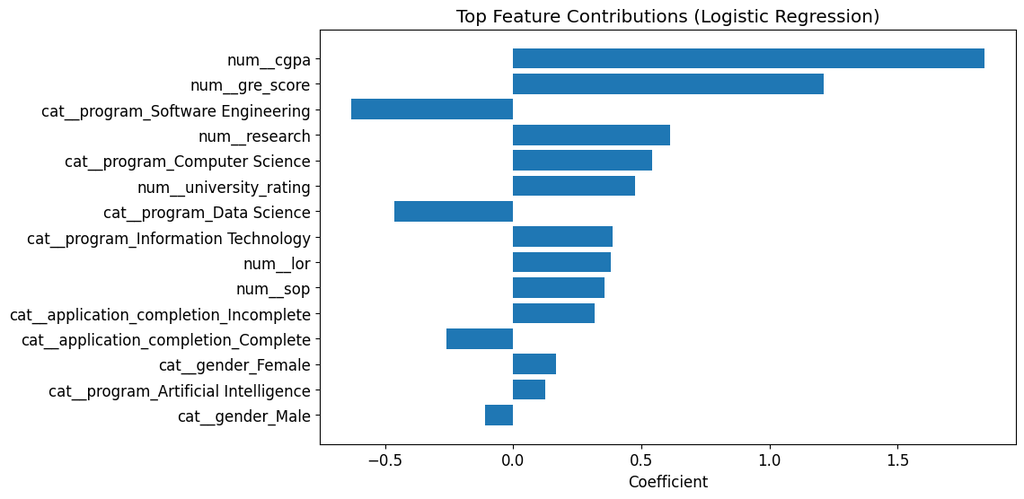

```python
top_features = coef_df.sort_values(
    by="Coefficient",
    key=abs,
    ascending=False
).head(15)

plt.figure(figsize=(10, 6))

plt.barh(
    top_features["Feature"],
    top_features["Coefficient"]
)

plt.title("Top Feature Contributions (Logistic Regression)")
plt.xlabel("Coefficient")

plt.gca().invert_yaxis()

plt.show()
```

**Step 8.4 – Save the Coefficients**

```python
coef_df.to_csv(
    "logistic_coefficients.csv",
    index=False
)

print("Coefficient report saved.")
```

```
Coefficient report saved.
```

**Step 8.5 – Calculate Prediction Probability**

```python
# Prediction probability for the first applicant in the test set
probability = best_model.predict_proba(
    X_test_processed[:1]
)[0][1]

print(f"Admission Probability: {probability:.2%}")
```

```
Admission Probability: 89.58%
```

**Step 8.6 – Create a Simple Rule-Based Explanation Function**

```python
def generate_explanation(applicant):
    """
    Generate a simple explanation for an applicant profile.
    """

    reasons = []

    if applicant["cgpa"] >= 9:
        reasons.append(
            "Excellent CGPA increased admission likelihood."
        )

    if applicant["gre_score"] >= 325:
        reasons.append(
            "High GRE score strengthened the prediction."
        )

    if applicant["toefl_score"] >= 110:
        reasons.append(
            "Strong TOEFL score improved the application."
        )

    if applicant["research"] == 1:
        reasons.append(
            "Research experience positively influenced the model."
        )

    if applicant["application_completion"] == "Complete":
        reasons.append(
            "A complete application strengthened the prediction."
        )

    if len(reasons) == 0:
        reasons.append(
            "No particularly strong positive indicators were detected."
        )

    return reasons
```

**Step 8.7 – Test the function**

```python
sample_candidate = {
    "gre_score": 330,
    "toefl_score": 114,
    "cgpa": 9.4,
    "research": 1,
    "application_completion": "Complete"
}

generate_explanation(sample_candidate)
```

```
['Excellent CGPA increased admission likelihood.',
 'High GRE score strengthened the prediction.',
 'Strong TOEFL score improved the application.',
 'Research experience positively influenced the model.',
 'A complete application strengthened the prediction.']
```

**Step 8.8 – Save Explainability Assets**

```python
coef_df.to_csv(
    "logistic_regression_coefficients.csv",
    index=False
)

print("Coefficient table saved.")
```

```
Coefficient table saved.
```